# SkyTrack - Flight & Airport Analysis

Lalit

2026-11-03

# 1. Introduction

Flight operations generate large amounts of data related to airlines, airports, flight schedules, delays and travel distances.

This project focuses on analysing flight records using R Programming. It aims to identify patterns in airline performance, airport traffic and flight delays through data analysis and visualization.

## 1.1 Problem Statement

Raw flight datasets contain information that can be difficult to understand without proper analysis.

This project uses R Programming to clean, analyse and visualize flight data to identify important patterns and understand flight operational performance.

## 1.3 Dataset Information

The project uses a flight dataset containing 1,000 records and 11 original columns.

The dataset includes information about:

- Flight identification
- Flight date
- Airline name
- Origin airport
- Destination airport
- Scheduled departure time
- Actual departure time
- Departure delay
- Arrival delay
- Flight distance
- Flight status

The dataset contains simulated flight records and is used for academic analysis and visualization.

# 2. Install and Load Packages

R Programming provides several packages for data manipulation, statistical analysis and visualization.

The following packages will be used in this project.

```r
packages <- c(
  "tidyverse",
  "dplyr",
  "tidyr",
  "ggplot2",
  "readr",
  "lubridate",
  "knitr",
  "DT",
  "plotly"
)

new_packages <- packages[
  !(packages %in% installed.packages()[, "Package"])
]

if(length(new_packages) > 0) {
  install.packages(new_packages)
}

library(dplyr)
library(tidyr)
library(lubridate)
library(ggplot2)
library(plotly)
library(DT)
library(knitr)
```

## 2.1 Packages Used

| Package | Purpose |
| --- | --- |
| tidyverse | Data manipulation |
| dplyr | Data analysis |
| tidyr | Data cleaning |
| ggplot2 | Data visualization |
| readr | CSV file import |
| lubridate | Date and time analysis |
| plotly | Interactive charts |
| DT | Interactive data tables |
| knitr | Report generation |

# 3. Import Dataset

The flight dataset is imported into R using the read_csv() function from the readr package.

```r
flights <- readr::read_csv("flights-1000.csv")
head(flights)
```

| flight_id | flight_date | airline | origin | destination | scheduled_dep | actual_dep | dep_delay_min | arr_delay_min | distance_km | status |
| --- | --- | --- | --- | --- | --- | --- | --- | --- | --- | --- |
| BY2752 | 2026-01-01 | Blue Yonder | LAX | ATL | 2026-01-01 11:20:00 |  | NA | NA | 466 | cancelled |
| TR2153 | 2026-01-01 | Tailspin Regional | PHX | CMH | 2026-01-01 12:10:00 | 2026-01-01 12:21:00 | 11 | 20 | 504 | on time |
| AW3023 | 2026-01-01 | Adventure Works Air | SAN | BOS | 2026-01-01 07:45:00 | 2026-01-01 07:52:00 | 7 | 0 | 1391 | on time |
| NW4729 | 2026-01-02 | Northwind Air | SEA | DEN | 2026-01-02 07:55:00 | 2026-01-02 10:37:00 | 162 | 146 | 1079 | delayed |
| TR3903 | 2026-01-02 | Tailspin Regional | CMH | SEA | 2026-01-02 22:20:00 | 2026-01-02 22:13:00 | -7 | 7 | 1290 | on time |
| PR3582 | 2026-01-02 | Proseware Airlines | BOS | RDU | 2026-01-02 16:00:00 | 2026-01-02 15:58:00 | -2 | -5 | 1181 | on time |

## 3.1 Dataset Structure

The structure of the dataset is examined to understand its columns and data types.

```r
str(flights)
```

```
## spc_tbl_ [1,000 × 11] (S3: spec_tbl_df/tbl_df/tbl/data.frame)
##  $ flight_id    : chr [1:1000] "BY2752" "TR2153" "AW3023" "NW4729" ...
##  $ flight_date  : Date[1:1000], format: "2026-01-01" "2026-01-01" ...
##  $ airline      : chr [1:1000] "Blue Yonder" "Tailspin Regional" "Adventure Works Air" "Northwind Air" ...
##  $ origin       : chr [1:1000] "LAX" "PHX" "SAN" "SEA" ...
##  $ destination  : chr [1:1000] "ATL" "CMH" "BOS" "DEN" ...
##  $ scheduled_dep: POSIXct[1:1000], format: "2026-01-01 11:20:00" "2026-01-01 12:10:00" ...
##  $ actual_dep   : POSIXct[1:1000], format: NA "2026-01-01 12:21:00" ...
##  $ dep_delay_min: num [1:1000] NA 11 7 162 -7 -2 29 -7 2 55 ...
##  $ arr_delay_min: num [1:1000] NA 20 0 146 7 -5 15 -19 -15 60 ...
##  $ distance_km  : num [1:1000] 466 504 1391 1079 1290 ...
##  $ status       : chr [1:1000] "cancelled" "on time" "on time" "delayed" ...
##  - attr(*, "spec")=
##   .. cols(
##   ..   flight_id = col_character(),
##   ..   flight_date = col_date(format = ""),
##   ..   airline = col_character(),
##   ..   origin = col_character(),
##   ..   destination = col_character(),
##   ..   scheduled_dep = col_datetime(format = ""),
##   ..   actual_dep = col_datetime(format = ""),
##   ..   dep_delay_min = col_double(),
##   ..   arr_delay_min = col_double(),
##   ..   distance_km = col_double(),
##   ..   status = col_character()
##   .. )
##  - attr(*, "problems")=<pointer: 0x0000028a9e7ef620>
```

## 3.2 Dataset Dimensions

```r
cat("Number of Rows:", nrow(flights))
```

```
## Number of Rows: 1000
```

```r
cat("\nNumber of Columns:", ncol(flights))
```

```
##
## Number of Columns: 11
```

# 4. Exploratory Data Analysis

Exploratory Data Analysis (EDA) is used to understand the structure, characteristics and patterns present in the flight dataset.

## 4.1 Dataset Overview

```r
cat("Total Rows:", nrow(flights))
```

```
## Total Rows: 1000
```

```r
cat("\nTotal Columns:", ncol(flights))
```

```
##
## Total Columns: 11
```

```r
head(flights)
```

| flight_id | flight_date | airline | origin | destination | scheduled_dep | actual_dep | dep_delay_min | arr_delay_min | distance_km | status |
| --- | --- | --- | --- | --- | --- | --- | --- | --- | --- | --- |
| BY2752 | 2026-01-01 | Blue Yonder | LAX | ATL | 2026-01-01 11:20:00 |  | NA | NA | 466 | cancelled |
| TR2153 | 2026-01-01 | Tailspin Regional | PHX | CMH | 2026-01-01 12:10:00 | 2026-01-01 12:21:00 | 11 | 20 | 504 | on time |
| AW3023 | 2026-01-01 | Adventure Works Air | SAN | BOS | 2026-01-01 07:45:00 | 2026-01-01 07:52:00 | 7 | 0 | 1391 | on time |
| NW4729 | 2026-01-02 | Northwind Air | SEA | DEN | 2026-01-02 07:55:00 | 2026-01-02 10:37:00 | 162 | 146 | 1079 | delayed |
| TR3903 | 2026-01-02 | Tailspin Regional | CMH | SEA | 2026-01-02 22:20:00 | 2026-01-02 22:13:00 | -7 | 7 | 1290 | on time |
| PR3582 | 2026-01-02 | Proseware Airlines | BOS | RDU | 2026-01-02 16:00:00 | 2026-01-02 15:58:00 | -2 | -5 | 1181 | on time |

## 4.2 Statistical Summary

```r
summary(flights)
```

```
##      flight_id     flight_date              airline           origin
##  Length   :1000   Min.   :2026-01-01   Length   :1000   Length   :1000
##  N.unique : 987   1st Qu.:2026-03-02   N.unique :   8   N.unique :  16
##  N.blank  :   0   Median :2026-04-30   N.blank  :   0   N.blank  :   0
##  Min.nchar:   5   Mean   :2026-04-30   Min.nchar:  11   Min.nchar:   3
##  Max.nchar:   6   3rd Qu.:2026-06-29   Max.nchar:  19   Max.nchar:   3
##                   Max.   :2026-08-28
##
##     destination   scheduled_dep                   actual_dep
##  Length   :1000   Min.   :2026-01-01 07:45:00   Min.   :2026-01-01 07:52:00
##  N.unique :  16   1st Qu.:2026-03-02 09:16:15   1st Qu.:2026-03-02 17:45:00
##  N.blank  :   0   Median :2026-05-01 00:30:00   Median :2026-04-30 17:54:00
##  Min.nchar:   3   Mean   :2026-05-01 01:54:37   Mean   :2026-05-01 02:47:05
##  Max.nchar:   3   3rd Qu.:2026-06-29 11:30:00   3rd Qu.:2026-06-29 06:24:00
##                   Max.   :2026-08-28 15:40:00   Max.   :2026-08-28 17:07:00
##                                                 NAs    :21
##  dep_delay_min   arr_delay_min     distance_km         status
##  Min.   :-12.0   Min.   :-29.00   Min.   : 411   Length   :1000
##  1st Qu.: -3.0   1st Qu.: -7.00   1st Qu.: 794   N.unique :   4
##  Median :  6.0   Median :  6.00   Median :1216   N.blank  :   0
##  Mean   : 24.8   Mean   : 22.47   Mean   :1372   Min.nchar:   7
##  3rd Qu.: 35.0   3rd Qu.: 35.00   3rd Qu.:1804   Max.nchar:   9
##  Max.   :231.0   Max.   :237.00   Max.   :4205
##  NAs    :21      NAs    :21
```

## 4.3 Missing Value Analysis

```r
missing_values <- data.frame(
  Column = names(flights),
  Missing_Count = colSums(is.na(flights))
)

knitr::kable(
  missing_values,
  caption = "Missing Values in Flight Dataset"
)
```

Missing Values in Flight Dataset

|  | Column | Missing_Count |
| --- | --- | --- |
| flight_id | flight_id | 0 |
| flight_date | flight_date | 0 |
| airline | airline | 0 |
| origin | origin | 0 |
| destination | destination | 0 |
| scheduled_dep | scheduled_dep | 0 |
| actual_dep | actual_dep | 21 |
| dep_delay_min | dep_delay_min | 21 |
| arr_delay_min | arr_delay_min | 21 |
| distance_km | distance_km | 0 |
| status | status | 0 |

## 4.4 Duplicate Record Analysis

```r
duplicate_count <- sum(duplicated(flights))

cat("Total Duplicate Records:", duplicate_count)
```

```
## Total Duplicate Records: 0
```

## 4.5 Flight Status Distribution

```r
status_analysis <- flights %>%
  count(status, name = "Total_Flights")

knitr::kable(
  status_analysis,
  caption = "Flight Status Distribution"
)
```

Flight Status Distribution

| status | Total_Flights |
| --- | --- |
| cancelled | 21 |
| delayed | 332 |
| diverted | 6 |
| on time | 641 |

# 5. Data Cleaning and Transformation

## 5.1 Convert Data Types

```r
flights$flight_date <- as.Date(flights$flight_date)

flights$airline <- as.factor(flights$airline)
flights$origin <- as.factor(flights$origin)
flights$destination <- as.factor(flights$destination)
flights$status <- as.factor(flights$status)

str(flights)
```

```
## spc_tbl_ [1,000 × 11] (S3: spec_tbl_df/tbl_df/tbl/data.frame)
##  $ flight_id    : chr [1:1000] "BY2752" "TR2153" "AW3023" "NW4729" ...
##  $ flight_date  : Date[1:1000], format: "2026-01-01" "2026-01-01" ...
##  $ airline      : Factor w/ 8 levels "Adventure Works Air",..: 2 8 1 6 8 7 2 1 8 1 ...
##  $ origin       : Factor w/ 16 levels "ATL","AUS","BNA",..: 9 13 15 16 5 4 4 1 3 3 ...
##  $ destination  : Factor w/ 16 levels "ATL","AUS","BNA",..: 1 5 4 6 16 14 13 9 7 14 ...
##  $ scheduled_dep: POSIXct[1:1000], format: "2026-01-01 11:20:00" "2026-01-01 12:10:00" ...
##  $ actual_dep   : POSIXct[1:1000], format: NA "2026-01-01 12:21:00" ...
##  $ dep_delay_min: num [1:1000] NA 11 7 162 -7 -2 29 -7 2 55 ...
##  $ arr_delay_min: num [1:1000] NA 20 0 146 7 -5 15 -19 -15 60 ...
##  $ distance_km  : num [1:1000] 466 504 1391 1079 1290 ...
##  $ status       : Factor w/ 4 levels "cancelled","delayed",..: 1 4 4 2 4 4 2 4 4 2 ...
##  - attr(*, "spec")=
##   .. cols(
##   ..   flight_id = col_character(),
##   ..   flight_date = col_date(format = ""),
##   ..   airline = col_character(),
##   ..   origin = col_character(),
##   ..   destination = col_character(),
##   ..   scheduled_dep = col_datetime(format = ""),
##   ..   actual_dep = col_datetime(format = ""),
##   ..   dep_delay_min = col_double(),
##   ..   arr_delay_min = col_double(),
##   ..   distance_km = col_double(),
##   ..   status = col_character()
##   .. )
##  - attr(*, "problems")=<pointer: 0x0000028a9e7ef620>
```

## 5.2 Create New Columns

```r
flights <- flights %>%
  mutate(
    month = lubridate::month(flight_date, label = TRUE),
    weekday = lubridate::wday(flight_date, label = TRUE)
  )

head(flights)
```

| flight_id | flight_date | airline | origin | destination | scheduled_dep | actual_dep | dep_delay_min | arr_delay_min | distance_km | status | month | weekday |
| --- | --- | --- | --- | --- | --- | --- | --- | --- | --- | --- | --- | --- |
| BY2752 | 2026-01-01 | Blue Yonder | LAX | ATL | 2026-01-01 11:20:00 |  | NA | NA | 466 | cancelled | Jan | Thu |
| TR2153 | 2026-01-01 | Tailspin Regional | PHX | CMH | 2026-01-01 12:10:00 | 2026-01-01 12:21:00 | 11 | 20 | 504 | on time | Jan | Thu |
| AW3023 | 2026-01-01 | Adventure Works Air | SAN | BOS | 2026-01-01 07:45:00 | 2026-01-01 07:52:00 | 7 | 0 | 1391 | on time | Jan | Thu |
| NW4729 | 2026-01-02 | Northwind Air | SEA | DEN | 2026-01-02 07:55:00 | 2026-01-02 10:37:00 | 162 | 146 | 1079 | delayed | Jan | Fri |
| TR3903 | 2026-01-02 | Tailspin Regional | CMH | SEA | 2026-01-02 22:20:00 | 2026-01-02 22:13:00 | -7 | 7 | 1290 | on time | Jan | Fri |
| PR3582 | 2026-01-02 | Proseware Airlines | BOS | RDU | 2026-01-02 16:00:00 | 2026-01-02 15:58:00 | -2 | -5 | 1181 | on time | Jan | Fri |

## 5.3 Missing Values After Cleaning

```r
missing_after_cleaning <- data.frame(
  Column = names(flights),
  Missing_Values = colSums(is.na(flights))
)

knitr::kable(
  missing_after_cleaning,
  caption = "Missing Values After Data Preparation"
)
```

Missing Values After Data Preparation

|  | Column | Missing_Values |
| --- | --- | --- |
| flight_id | flight_id | 0 |
| flight_date | flight_date | 0 |
| airline | airline | 0 |
| origin | origin | 0 |
| destination | destination | 0 |
| scheduled_dep | scheduled_dep | 0 |
| actual_dep | actual_dep | 21 |
| dep_delay_min | dep_delay_min | 21 |
| arr_delay_min | arr_delay_min | 21 |
| distance_km | distance_km | 0 |
| status | status | 0 |
| month | month | 0 |
| weekday | weekday | 0 |

## 5.4 Data Type Verification

```r
data_types <- data.frame(
  Column = names(flights),
  Data_Type = sapply(flights, function(x) class(x)[1])
)

knitr::kable(
  data_types,
  caption = "Dataset Column Data Types"
)
```

Dataset Column Data Types

|  | Column | Data_Type |
| --- | --- | --- |
| flight_id | flight_id | character |
| flight_date | flight_date | Date |
| airline | airline | factor |
| origin | origin | factor |
| destination | destination | factor |
| scheduled_dep | scheduled_dep | POSIXct |
| actual_dep | actual_dep | POSIXct |
| dep_delay_min | dep_delay_min | numeric |
| arr_delay_min | arr_delay_min | numeric |
| distance_km | distance_km | numeric |
| status | status | factor |
| month | month | ordered |
| weekday | weekday | ordered |

## 5.5 Final Dataset Overview

```r
cat("Total Records:", nrow(flights))
```

```
## Total Records: 1000
```

```r
cat("\nTotal Columns:", ncol(flights))
```

```
##
## Total Columns: 13
```

```r
cat("\nDuplicate Records:", sum(duplicated(flights)))
```

```
##
## Duplicate Records: 0
```

# 6. Data Visualization

Data visualization helps identify patterns and trends in airline operations and airport activities.

## 6.1 Airline-wise Flight Distribution

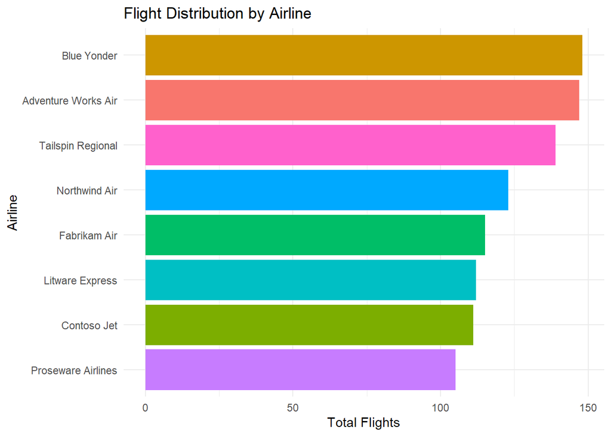

```r
airline_count <- flights %>%
  count(airline, name = "Total_Flights")

ggplot(airline_count,
       aes(x = reorder(airline, Total_Flights),
           y = Total_Flights,
           fill = airline)) +
  geom_col() +
  coord_flip() +
  labs(
    title = "Flight Distribution by Airline",
    x = "Airline",
    y = "Total Flights"
  ) +
  theme_minimal() +
  theme(legend.position = "none")
```

## 6.2 Average Departure Delay by Airline

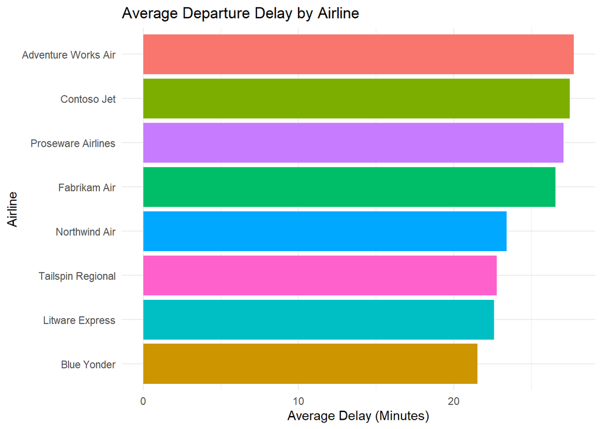

```r
airline_delay <- flights %>%
  group_by(airline) %>%
  summarise(
    Average_Delay = mean(dep_delay_min, na.rm = TRUE)
  )

ggplot(airline_delay,
       aes(x = reorder(airline, Average_Delay),
           y = Average_Delay,
           fill = airline)) +
  geom_col() +
  coord_flip() +
  labs(
    title = "Average Departure Delay by Airline",
    x = "Airline",
    y = "Average Delay (Minutes)"
  ) +
  theme_minimal() +
  theme(legend.position = "none")
```

## 6.3 Top 10 Busiest Origin Airports

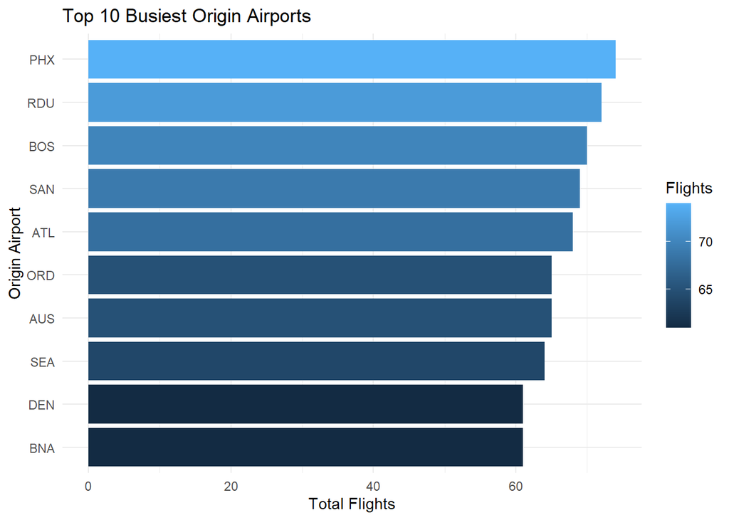

```r
airport_traffic <- flights %>%
  count(origin, name = "Total_Flights") %>%
  arrange(desc(Total_Flights)) %>%
  slice_head(n = 10)

ggplot(airport_traffic,
       aes(x = reorder(origin, Total_Flights),
           y = Total_Flights,
           fill = Total_Flights)) +
  geom_col() +
  coord_flip() +
  labs(
    title = "Top 10 Busiest Origin Airports",
    x = "Origin Airport",
    y = "Total Flights",
    fill = "Flights"
  ) +
  theme_minimal()
```

## 6.4 Flight Status Distribution

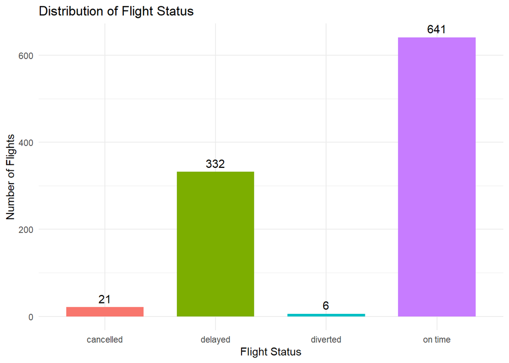

```r
status_analysis <- flights %>%
  count(status, name = "Total_Flights")

ggplot(status_analysis,
       aes(x = status, y = Total_Flights, fill = status)) +
  geom_col(width = 0.7) +
  geom_text(
    aes(label = Total_Flights),
    vjust = -0.5,
    size = 4
  ) +
  labs(
    title = "Distribution of Flight Status",
    x = "Flight Status",
    y = "Number of Flights"
  ) +
  theme_minimal() +
  theme(legend.position = "none")
```

## 6.5 Monthly Flight Trends

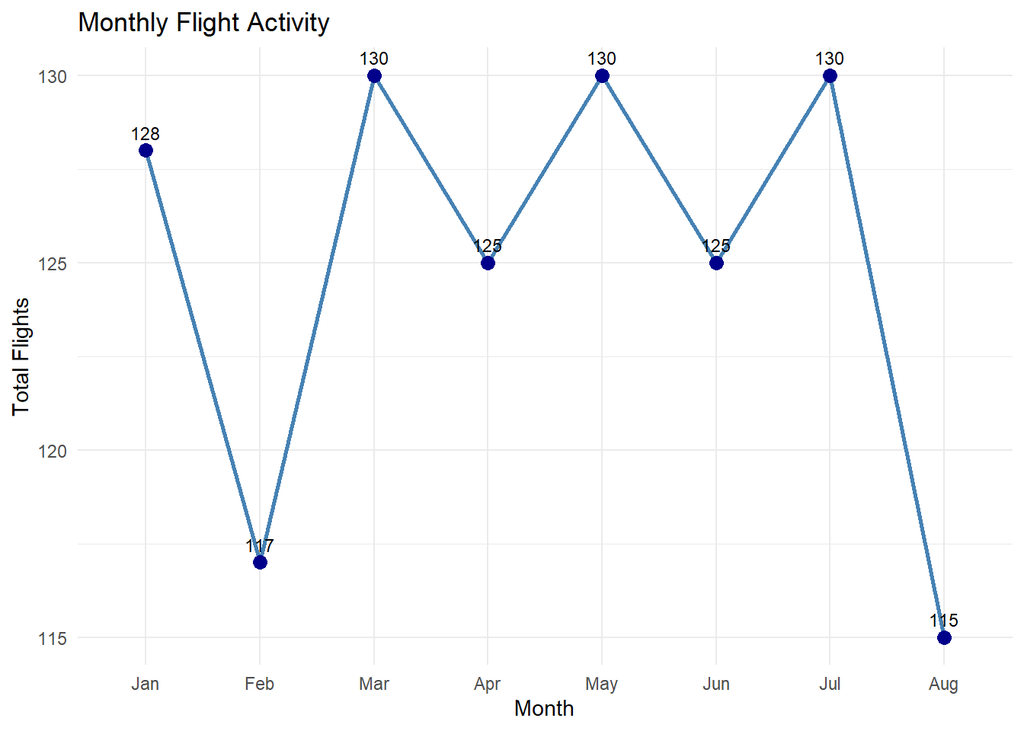

```r
monthly_flights <- flights %>%
  count(month, name = "Total_Flights")

ggplot(monthly_flights,
       aes(x = month, y = Total_Flights, group = 1)) +
  geom_line(linewidth = 1, color = "steelblue") +
  geom_point(size = 3, color = "darkblue") +
  geom_text(
    aes(label = Total_Flights),
    vjust = -0.8,
    size = 3
  ) +
  labs(
    title = "Monthly Flight Activity",
    x = "Month",
    y = "Total Flights"
  ) +
  theme_minimal()
```

# 7. Statistical Analysis and Key Insights

## 7.1 Airline Performance Analysis

```r
airline_performance <- flights %>%
  group_by(airline) %>%
  summarise(
    Total_Flights = n(),
    Average_Departure_Delay = round(
      mean(dep_delay_min, na.rm = TRUE), 2
    ),
    Average_Arrival_Delay = round(
      mean(arr_delay_min, na.rm = TRUE), 2
    ),
    .groups = "drop"
  ) %>%
  arrange(desc(Total_Flights))

knitr::kable(
  airline_performance,
  caption = "Airline Performance Analysis"
)
```

Airline Performance Analysis

| airline | Total_Flights | Average_Departure_Delay | Average_Arrival_Delay |
| --- | --- | --- | --- |
| Blue Yonder | 148 | 21.54 | 18.85 |
| Adventure Works Air | 147 | 27.74 | 24.12 |
| Tailspin Regional | 139 | 22.78 | 21.28 |
| Northwind Air | 123 | 23.41 | 20.46 |
| Fabrikam Air | 115 | 26.57 | 24.76 |
| Litware Express | 112 | 22.61 | 21.13 |
| Contoso Jet | 111 | 27.47 | 25.13 |
| Proseware Airlines | 105 | 27.07 | 25.25 |

## 7.2 Airport Traffic Analysis

```r
airport_analysis <- flights %>%
  group_by(origin) %>%
  summarise(
    Total_Departures = n(),
    Average_Delay = round(
      mean(dep_delay_min, na.rm = TRUE), 2
    ),
    .groups = "drop"
  ) %>%
  arrange(desc(Total_Departures))

knitr::kable(
  head(airport_analysis, 10),
  caption = "Top 10 Airports by Departure Traffic"
)
```

Top 10 Airports by Departure Traffic

| origin | Total_Departures | Average_Delay |
| --- | --- | --- |
| PHX | 74 | 22.55 |
| RDU | 72 | 36.96 |
| BOS | 70 | 24.40 |
| SAN | 69 | 22.60 |
| ATL | 68 | 24.83 |
| AUS | 65 | 23.29 |
| ORD | 65 | 30.02 |
| SEA | 64 | 23.19 |
| BNA | 61 | 20.62 |
| DEN | 61 | 18.69 |

## 7.3 Overall Flight Statistics

```r
overall_statistics <- flights %>%
  summarise(
    Total_Flights = n(),
    Average_Departure_Delay = round(
      mean(dep_delay_min, na.rm = TRUE), 2
    ),
    Average_Arrival_Delay = round(
      mean(arr_delay_min, na.rm = TRUE), 2
    ),
    Average_Distance_KM = round(
      mean(distance_km, na.rm = TRUE), 2
    )
  )

knitr::kable(
  overall_statistics,
  caption = "Overall Flight Statistics"
)
```

Overall Flight Statistics

| Total_Flights | Average_Departure_Delay | Average_Arrival_Delay | Average_Distance_KM |
| --- | --- | --- | --- |
| 1000 | 24.8 | 22.47 | 1371.93 |

# 8. Key Findings

The analysis of the flight dataset provides the following important observations:

- The dataset contains 1,000 simulated flight records.
- Flight status analysis helps compare on-time, delayed, cancelled and diverted flights.
- Airline performance analysis compares flight volumes and average departure and arrival delays.
- Airport traffic analysis identifies the busiest origin airports.
- Monthly analysis highlights changes in flight activity.
- Data quality analysis identifies missing values and duplicate records.

# 9. Conclusion

The SkyTrack project demonstrates how R Programming can be used for flight data analysis and visualization.

The project covers data importing, data cleaning, exploratory data analysis, statistical analysis and graphical representation.

The visualizations and analytical tables help understand airline activity, airport traffic, flight delays and monthly flight trends.

This project provides practical experience in using R packages such as dplyr, tidyr, ggplot2, lubridate and plotly.

Since the dataset contains simulated records, the findings are intended for academic analysis and do not represent actual airline performance.

# 10. References

1. R Programming Documentation – https://www.r-project.org/
2. Tidyverse Documentation – https://www.tidyverse.org/
3. ggplot2 Documentation – https://ggplot2.tidyverse.org/
4. dplyr Documentation – https://dplyr.tidyverse.org/
5. RStudio Documentation – https://posit.co/